# Does Trump’s inaugural speech indicate his second term in office?

## 2 - Length of Sentences

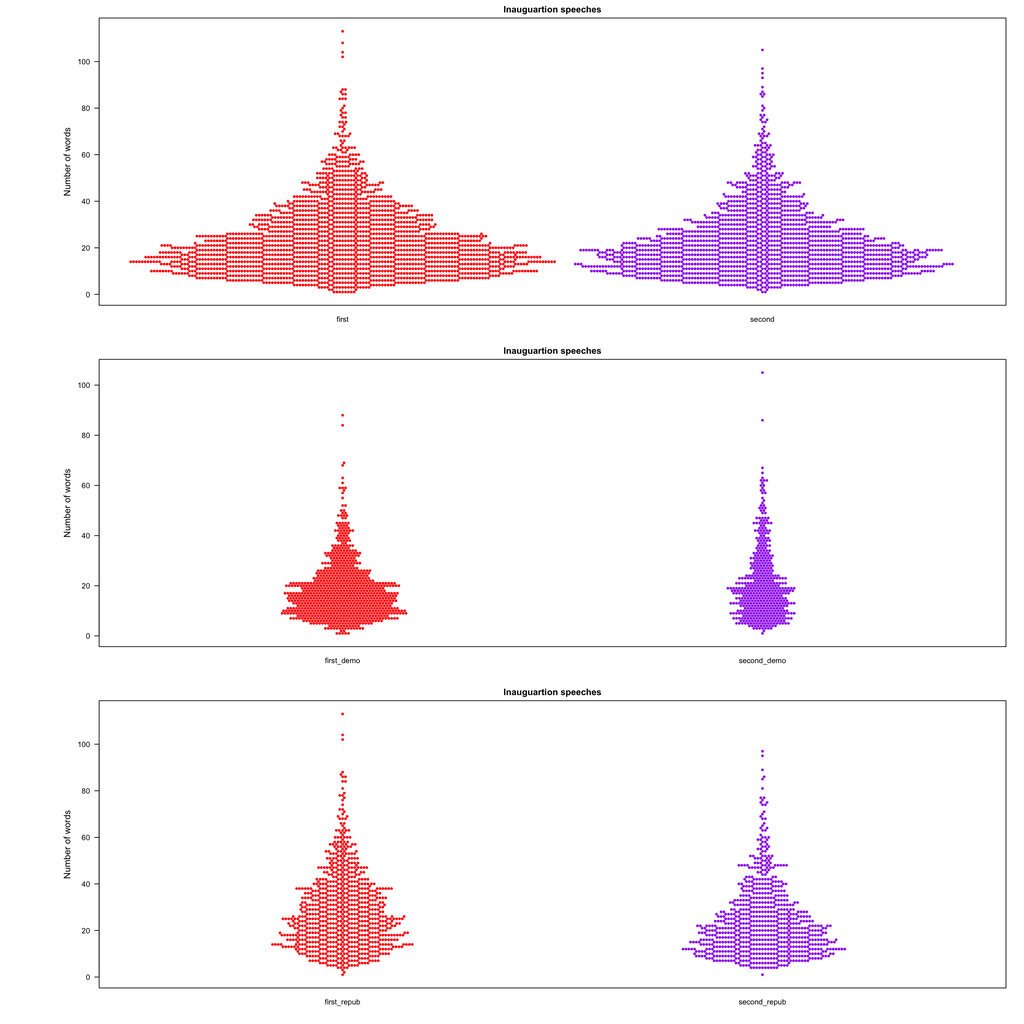

```r
###sentence.list         sentence list of all file in dir
###sentence.list.all     sentence list of all file group by one-term and second-term
###setence.list.demo
###setence.list.repub

#par(mar=c(4, 11, 2, 2))
par(mfrow=c(3,1),mar=c(4, 11, 2, 2))


###all
sentence.list.all=filter(sentence.list, File%in%c(first_term$File,second_term$File))
sentence.list.all$Group=ifelse(sentence.list.all$File%in%first_term$File,"first","second")
#sentence.list.all$avg.word<-ifelse(sentence.list.all$Group=="first",sentence.list.all$word.count/length(first),sentence.list.all$word.count/length(second))

beeswarm(word.count~Group,
         data=sentence.list.all,
         horizontal = FALSE,
         pch=16, col=c("red","purple"),
         cex=0.8, cex.axis=1, cex.lab=1.2,
         las=2,ylab="Number of words",
         xlab="",las=1,
         main="Inauguartion speeches")

###demo
sentence.list.demo=filter(sentence.list, File%in%c(first_term_demo$File,second_term_demo$File))
sentence.list.demo$Group=ifelse(sentence.list.demo$File%in%first_term_demo$File,"first_demo","second_demo")
#sentence.list.demo$avg.word<-ifelse(sentence.list.demo$Group=="first_demo",sentence.list.demo$word.count/length(first_demo),sentence.list.demo$word.count/length(second_demo))
beeswarm(word.count~Group,
         data=sentence.list.demo,
         horizontal = FALSE,
         pch=16, col=c("red","purple"),
         cex=0.8, cex.axis=1, cex.lab=1.2,
         las=2,ylab="Number of words",
         xlab="",las=1,
         main="Inauguartion speeches")

###repub
sentence.list.repub=filter(sentence.list, File%in%c(first_term_repub$File,second_term_repub$File))
sentence.list.repub$Group=ifelse(sentence.list.repub$File%in%first_term_repub$File,"first_repub","second_repub")
#sentence.list.repub$avg.word<-ifelse(sentence.list.repub$Group=="first_repub",sentence.list.repub$word.count/length(first_repub),sentence.list.repub$word.count/length(second_repub))

beeswarm(word.count~Group,
         data=sentence.list.repub,
         horizontal = FALSE,
         pch=16, col=c("red","purple"),
         cex=0.8, cex.axis=1, cex.lab=1.2,
         las=2,ylab="Number of words",
         xlab="",las=1,
         main="Inauguartion speeches")
```

Only first inaugural speeches are picked. There are 23 one-term presidents **vs** 17 second-term presidents; 9 one-term democratic presidents **vs** 6 two-term democratic presidents; 10 one-term republican presidents **vs** 7 two-term republican presidents. As the number of presidents in each group differ, the analysis become more complicated. However, we can still see some patterns:

- All presidents will have more sentences with length around 20, have similar shape of distribution of sentence length.
- Two-term presidents tends to have relatively more number of sentence. We can see it through the first plot. Although there are 23 one-term presidents but 17 two-term presidents, there is no significant less sentences in two-term presidents.
- Two-term democratic presidents have **more even** structure of sentence length compared to one-term democratic presidents. However, two-term republican presidents have **less even** structure compared to one-term republican presidents.

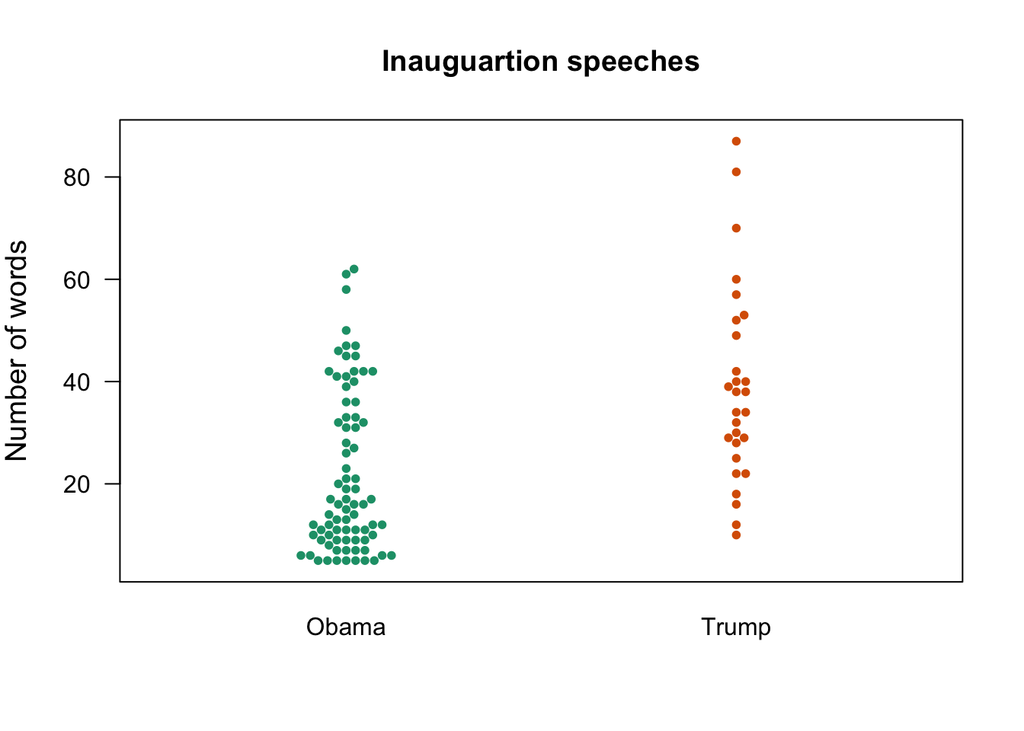

```r
###Trump
sentence.to=filter(sentence.list, File%in%c("DonaldJTrump","BarackObama"))
sentence.to$Group=ifelse(sentence.to$File=="DonaldJTrump","Trump","Obama")
beeswarm(sentence.to$word.count~Group,
         data=sentence.to,
         horizontal = FALSE,
         pch=16, col=brewer.pal(3,"Dark2"),
         cex=0.8, cex.axis=1, cex.lab=1.2,
         las=2,ylab="Number of words",
         xlab="",las=1,
         main="Inauguartion speeches")
```

Compared to Obama’s first-term inaugural speech, Trump has some extra long sentences. Trump has a specially even structure of sentence length which is closest the one-term republican presidents compared to other groups.